# Practical_Machine_Learning_project_RN

RNofal

Monday, April 25, 2016

# Introduction

The goal of your project is to predict the manner in which we did the exercise. The technology today helps us to monitor our activity, by using devices such as Jawbone Up, Nike FuelBand, and Fitbit is now possible to collect a large amount of data about personal activity relatively inexpensively. These type of devices are part of the quantified self movement â a group of enthusiasts who take measurements about themselves regularly to improve their health, to find patterns in their behavior, or because they are tech geeks. One thing that people regularly do is quantify how much of a particular activity they do, but they rarely quantify how well they do it. In this project, we will be to use data from accelerometers on the belt, forearm, arm, and dumbell of 6 participant They were asked to perform barbell lifts correctly and incorrectly in 5 different ways. The five ways are exactly according to the specification (Class A), throwing the elbows to the front (Class B), lifting the dumbbell only halfway (Class C), lowering the dumbbell only halfway (Class D) and throwing the hips to the front (Class E). Only Class A corresponds to correct performance. The goal of this project is to predict the manner in which they did the exercise, i.e., Class A to E. More information is available from the website here: http://groupware.les.inf.puc-rio.br/har (see the section on the Weight Lifting Exercise Dataset).

**`The goal of your project is to predict the manner in which they did the exercise.`** **`This is the "classe" variable in the training set.`**

### Required Libraries

```r
library(ggplot2)
library(datasets)
library(caret)
library(rattle)
library(randomForest) #Breiman and Cutler's Random Forests for Classification and Regression
library(repmis) # Automatically generate BibTeX files
library(rpart) #Recursive Partitioning and Regression Trees
library(rpart.plot) #Plot 'rpart' Models
```

### Loading traing and testing data from CSV files

```r
#interprete any string "NA" and "" to an NA value
train_data <- read.csv("pml-training.csv", na.strings = c("NA", ""))
test_data <- read.csv("pml-testing.csv", na.strings = c("NA", ""))
#print size of the data -number of rows- (observatition) and -number of column- variable
dim(train_data)
```

```
## [1] 19622   160
```

```r
dim(test_data)
```

```
## [1]  20 160
```

### Clean the data

First clean up all the columns that contains only “NA” value Then remove the first 7 columns that have nothing to do with prediction the value of classe

```r
clean_train_data <- train_data[, colSums(is.na(train_data)) == 0]
clean_test_data <- test_data[, colSums(is.na(test_data)) == 0]
clean_train_data <- clean_train_data[,-c(1:7)] #keep all columns except 1 to 7
clean_test_data <- clean_test_data[,-c(1:7)]
#print size of the data -number of rows- (observatition) and -number of column- variable after the clean up
dim(clean_train_data)
```

```
## [1] 19622    53
```

```r
dim(clean_test_data)
```

```
## [1] 20 53
```

### Spliting the training data to train

The split the training data into 2 sets 70% training and 30% validation Using the folloing seed 1234

```r
set.seed(1234)
trainTemp <- createDataPartition(clean_train_data$classe, p = 0.7, list = FALSE)
train_set <- clean_train_data[trainTemp,]
valid_set <- clean_train_data[-trainTemp,]
```

### Prediction using classification trees

When using k-fold cross validation it’s important to pick the value of k, here we use k=5.

```r
control <- trainControl(method = "cv", number = 5)
rpart_model <- train(classe ~ ., data=train_set, method="rpart",trControl = control)
print(rpart_model, digits = 4)
```

```
## CART
##
## 13737 samples
##    52 predictor
##     5 classes: 'A', 'B', 'C', 'D', 'E'
##
## No pre-processing
## Resampling: Cross-Validated (5 fold)
## Summary of sample sizes: 10990, 10988, 10991, 10990, 10989
## Resampling results across tuning parameters:
##
##   cp       Accuracy  Kappa
##   0.03550  0.5214    0.38010
##   0.06093  0.4175    0.21094
##   0.11738  0.3333    0.07467
##
## Accuracy was used to select the optimal model using  the largest value.
## The final value used for the model was cp = 0.0355.
```

### Ploting the classification tree

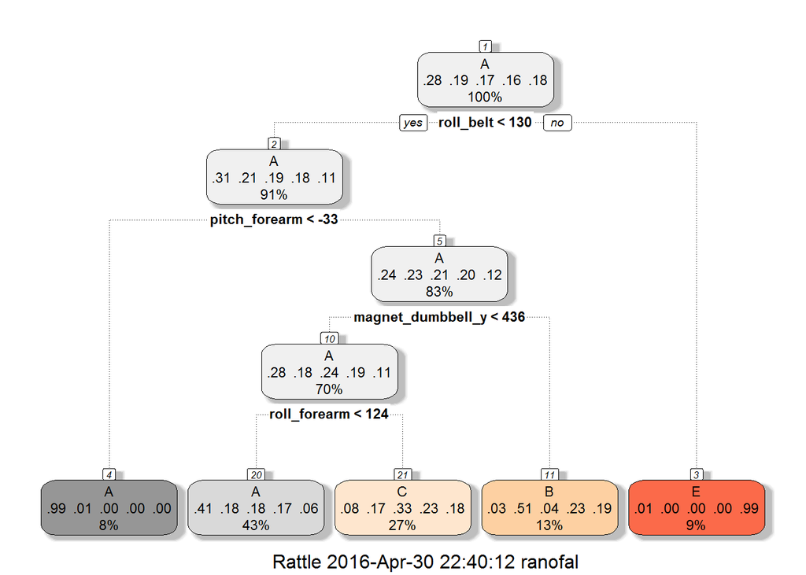

```r
fancyRpartPlot(rpart_model$finalModel,palettes=c("Greys", "Oranges"))
```

### Predict the value of “classe” using the validation set.

```r
prediction_results <- predict(rpart_model, valid_set)
```

### Show the confusion matrix.

```r
(confusion_matrix <- confusionMatrix(valid_set$classe, prediction_results))
```

```
## Confusion Matrix and Statistics
##
##           Reference
## Prediction    A    B    C    D    E
##          A 1530   35  105    0    4
##          B  486  379  274    0    0
##          C  493   31  502    0    0
##          D  452  164  348    0    0
##          E  168  145  302    0  467
##
## Overall Statistics
##
##                Accuracy : 0.489
##                  95% CI : (0.4762, 0.5019)
##     No Information Rate : 0.5317
##     P-Value [Acc > NIR] : 1
##
##                   Kappa : 0.3311
##  Mcnemar's Test P-Value : NA
##
## Statistics by Class:
##
##                      Class: A Class: B Class: C Class: D Class: E
## Sensitivity            0.4890   0.5027   0.3279       NA  0.99151
## Specificity            0.9478   0.8519   0.8797   0.8362  0.88641
## Pos Pred Value         0.9140   0.3327   0.4893       NA  0.43161
## Neg Pred Value         0.6203   0.9210   0.7882       NA  0.99917
## Prevalence             0.5317   0.1281   0.2602   0.0000  0.08003
## Detection Rate         0.2600   0.0644   0.0853   0.0000  0.07935
## Detection Prevalence   0.2845   0.1935   0.1743   0.1638  0.18386
## Balanced Accuracy      0.7184   0.6773   0.6038       NA  0.93896
```

### Model Accuracy

$\mbox{accuracy} = \frac{\mbox{# correctly classified data points}}{\mbox{# total data points}}$

### Accuracy of classification tree

```r
(accuracy_class_tree <- confusion_matrix$overall[1])
```

```
##  Accuracy
## 0.4890399
```

The classification tree accuracy **0.4890399** is really bad ### Using Random Forest

```r
random_forest_model <- train(classe ~ .,data=train_set, method="rf",trControl = control) #rf is random forest
print(random_forest_model, digits = 4)
```

```
## Random Forest
##
## 13737 samples
##    52 predictor
##     5 classes: 'A', 'B', 'C', 'D', 'E'
##
## No pre-processing
## Resampling: Cross-Validated (5 fold)
## Summary of sample sizes: 10991, 10989, 10989, 10990, 10989
## Resampling results across tuning parameters:
##
##   mtry  Accuracy  Kappa
##    2    0.9913    0.9889
##   27    0.9919    0.9898
##   52    0.9876    0.9843
##
## Accuracy was used to select the optimal model using  the largest value.
## The final value used for the model was mtry = 27.
```

### Predict the value of “classe” using the validation set.

```r
prediction_results <- predict(random_forest_model, valid_set)
```

### Show the confusion matrix.

```r
(confusion_matrix <- confusionMatrix(valid_set$classe, prediction_results))
```

```
## Confusion Matrix and Statistics
##
##           Reference
## Prediction    A    B    C    D    E
##          A 1674    0    0    0    0
##          B   12 1126    1    0    0
##          C    0    3 1019    4    0
##          D    0    1    5  957    1
##          E    0    1    2    3 1076
##
## Overall Statistics
##
##                Accuracy : 0.9944
##                  95% CI : (0.9921, 0.9961)
##     No Information Rate : 0.2865
##     P-Value [Acc > NIR] : < 2.2e-16
##
##                   Kappa : 0.9929
##  Mcnemar's Test P-Value : NA
##
## Statistics by Class:
##
##                      Class: A Class: B Class: C Class: D Class: E
## Sensitivity            0.9929   0.9956   0.9922   0.9927   0.9991
## Specificity            1.0000   0.9973   0.9986   0.9986   0.9988
## Pos Pred Value         1.0000   0.9886   0.9932   0.9927   0.9945
## Neg Pred Value         0.9972   0.9989   0.9984   0.9986   0.9998
## Prevalence             0.2865   0.1922   0.1745   0.1638   0.1830
## Detection Rate         0.2845   0.1913   0.1732   0.1626   0.1828
## Detection Prevalence   0.2845   0.1935   0.1743   0.1638   0.1839
## Balanced Accuracy      0.9964   0.9964   0.9954   0.9957   0.9989
```

```r
(accuracy_random_forest <- confusion_matrix$overall[1])
```

```
##  Accuracy
## 0.9943925
```

As we can see the random forest model accuracy is way much better than classification tree. The only issue it requires a lot of time to predict the data.

### Predicting the test set

Using the model random forest to predict test set

```r
(predict(random_forest_model, test_data))
```

```
##  [1] B A B A A E D B A A B C B A E E A B B B
## Levels: A B C D E
```